# Pisomka

Zuzana Wlachovská

21.4.2022

```r
data <- readxl::read_xlsx("p4.xlsx")
```

## Príklad 1

Tabuľka početností:

```r
rozdiely <- data$rozdiel
pocetnosti <- table(rozdiely)

pocetnosti
```

```
## rozdiely
## 0.01 0.03 0.05 0.08  0.1 0.12 0.13 0.14 0.15 0.17 0.18 0.19  0.2 0.21 0.22 0.24
##    1    2    1    1    2    2    1    1    2    2    4    2    1    3    5    4
## 0.25 0.26 0.27 0.29  0.3 0.31 0.33  0.4 0.41
##    3    2    1    1    4    2    1    1    1
```

Tabuľka relatívnych početností:

```r
relPocetnosti <- prop.table(rozdiely)

relPocetnosti
```

```
##  [1] 0.0183930300 0.0029041626 0.0116166505 0.0242013553 0.0232333011
##  [6] 0.0212971926 0.0242013553 0.0145208132 0.0164569216 0.0203291384
## [11] 0.0242013553 0.0212971926 0.0135527590 0.0174249758 0.0193610842
## [16] 0.0290416263 0.0174249758 0.0145208132 0.0232333011 0.0232333011
## [21] 0.0300096805 0.0387221684 0.0029041626 0.0212971926 0.0096805421
## [26] 0.0174249758 0.0300096805 0.0048402711 0.0251694095 0.0232333011
## [31] 0.0261374637 0.0290416263 0.0280735721 0.0077444337 0.0290416263
## [36] 0.0203291384 0.0164569216 0.0096805421 0.0319457890 0.0009680542
## [41] 0.0212971926 0.0251694095 0.0174249758 0.0125847047 0.0396902227
## [46] 0.0116166505 0.0203291384 0.0290416263 0.0183930300 0.0212971926
```

Charakteristiky polohy:

```r
summary(rozdiely)
```

```
##    Min. 1st Qu.  Median    Mean 3rd Qu.    Max.
##  0.0100  0.1550  0.2150  0.2066  0.2575  0.4100
```

Charakteristiky rozptylu:

```r
(varRozpatie <-  max(rozdiely) - min(rozdiely))
```

```
## [1] 0.4
```

```r
(medzikvartil <-  IQR(rozdiely))
```

```
## [1] 0.1025
```

```r
sd(rozdiely)
```

```
## [1] 0.08807719
```

Šikmosť a špicatosť:

```r
skewness(rozdiely)
```

```
## [1] -0.1540652
```

```r
kurtosis(rozdiely)
```

```
## [1] 0.149956
```

Keďže šikmosť, je skoro 0, dáta sú symetrické.

Histogram:

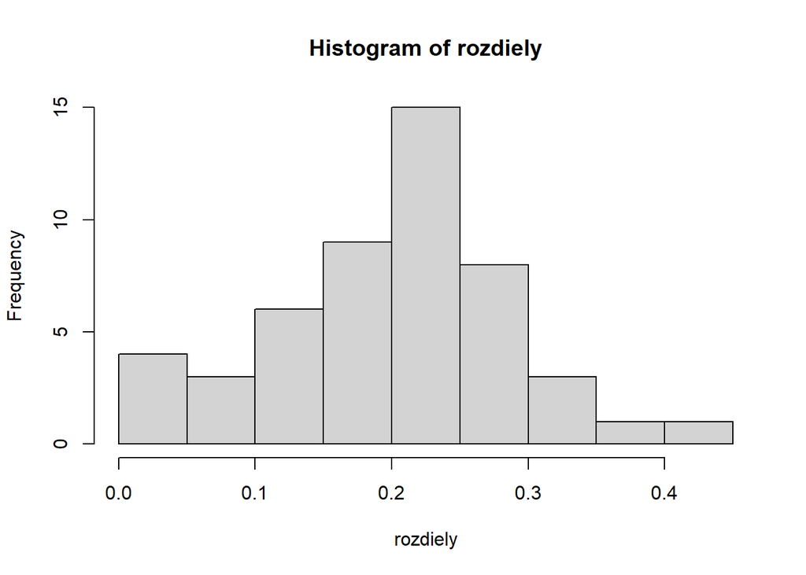

```r
hist(rozdiely)
```

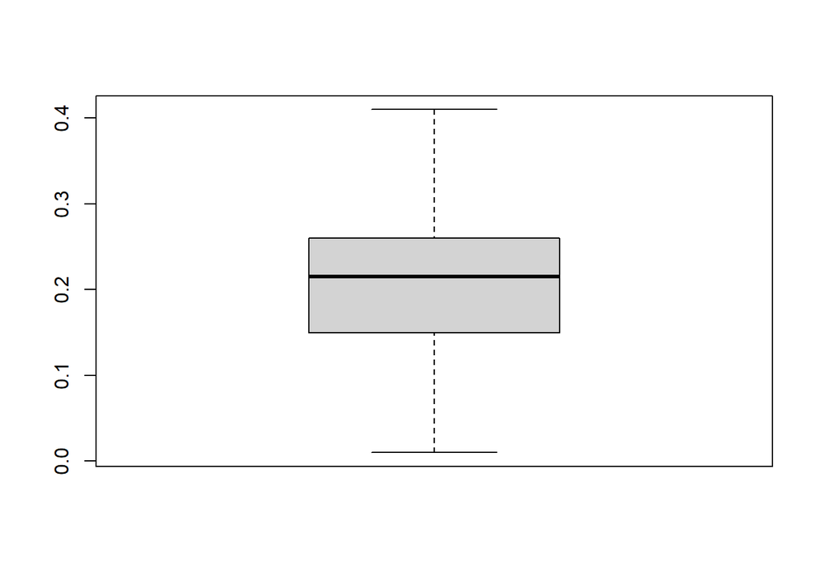

```r
boxplot(rozdiely)
```

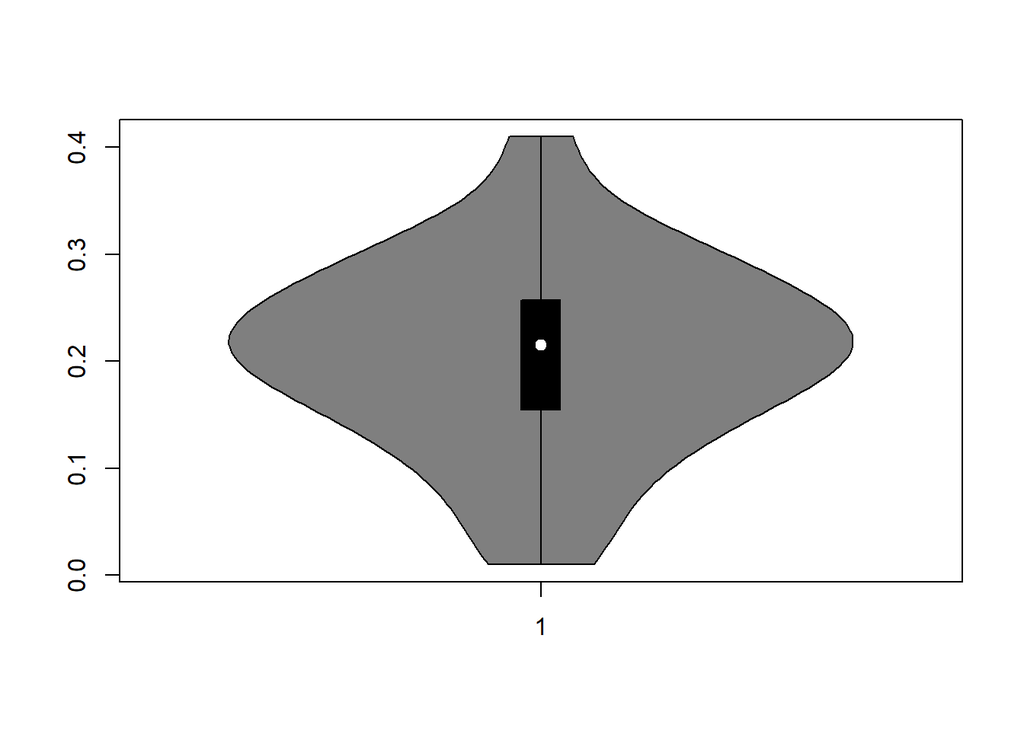

```r
vioplot(rozdiely)
```

Z boxplotu môžme vidieť, že nemám žiadne vybočujúce hodnoty. Ak by sme ich mali, boxpot by nám ukázal bodky, ktoré by boli mimo minima a maxima.

Z týchto grafov (vioplot, boxplot, histogram) môžme vidieť, že dáta sú pomerne symetrické (čo hovorí aj šikmosť), boxplot je pomerne v strede aj mean je v strede boxu, a vyzerajú byť aj normálne rozdelené keďže vioplot je pomerne symetrický ale normalitu by bolo treb overiť testom.

## Príklad 2

Keďže sú dáta symetrické použijem Shapito-Wilk test normality.

```r
shapiro.test(rozdiely)$p.value
```

```
## [1] 0.5824707
```

Keďže $p.value = 0.5824707 > \alpha = 0.05$, nezamietam $H_0$, že dáta sú normálne rozdelené.

Keďže sú dáta normálne rozdelené, idem robiť test pre strednú hodnotu.

Obojstranný interval spoľahlivosti:

```r
t.test(rozdiely)$conf.int
```

```
## [1] 0.1815687 0.2316313
## attr(,"conf.level")
## [1] 0.95
```

Z testu sme zistili, že 95% hodnôt (95% interval spoľahlivosti) sa nachádza v intervale $<0.1815687, 0.2316313>$

Ľavostranný interval spoľahlivosti:

```r
t.test(rozdiely, alternative = "greater")$conf.int
```

```
## [1] 0.1857169       Inf
## attr(,"conf.level")
## [1] 0.95
```

Z testu sme zistili, že 95% hodnôt sa nachádza v intervale $<0.1857169 ,\infty>$

Intervaly spoľahlivosti pre disperziu:

Obojstranný 95% interval spoľahlivosti:

```r
EnvStats::varTest(rozdiely)$conf.int
```

```
##         LCL         UCL
## 0.005413115 0.012046364
## attr(,"conf.level")
## [1] 0.95
```

```r
EnvStats::varTest(rozdiely, alternative = "greater")$conf.int
```

```
##         LCL         UCL
## 0.005730023         Inf
## attr(,"conf.level")
## [1] 0.95
```

## Príklad 3

Keďže sme v príklade 2 overili normality dát, môžme ísť testovať hypotézu o disperzii a strendej hodnote.

Test o strednej hodnote ak máme danú disperziu:

$$H_0 : \mu = 0.15(\leq0.15)\qquad H_1: \mu > 0.15$$

```r
ZTest(rozdiely, mu = 0.15, sd_pop = 0.05, alternative = "greater")
```

```
##
##  One Sample z-test
##
## data:  rozdiely
## z = 8.0044, Std. Dev. Population = 0.05, p-value = 6e-16
## alternative hypothesis: true mean is greater than 0.15
## 95 percent confidence interval:
##  0.1949691       Inf
## sample estimates:
## mean of x
##    0.2066
```

Test pre disperziu:

$$H_0 : \sigma = 0.05\qquad H_1: \sigma \neq 0.05$$

```r
varTest(rozdiely, sigma.squared = 0.05^2)$p.value
```

```
## [1] 3.492984e-12
```

```r
sd(rozdiely)
```

```
## [1] 0.08807719
```

Keďže $p.value = 3.492984e-12 < \alpha = 0.05$ zamietame $H_0$ o tom, že disperzia $= 0.05$. Ak by sme sa pozreli na bodový odhad disperzie, zistíme, že ten je 0.08807719.

Test pre $\mu$:

Keďže sme zistili, že disperzia nie je taká akú výrobca uvádza, vykonáme na strednú hodnotu iný test:

$$H_0 : \mu = 0.15(\leq0.15)\qquad H_1: \mu > 0.15$$

```r
t.test(rozdiely, mu = 0.15, alternative = "greater")$p.value
```

```
## [1] 1.810652e-05
```

Keďže $p.value = 1.810652e-05 < \alpha = 0.05$, zamietame $H_0$ o tom, že stredná hodnota tohto súboru $\leq 0.15$.

## Príklad 4

Na overenie náhodnosti použijeme 2 testy, jeden odhaľuje trendy v dátach a druhý periodicitu.

$$H_0: \text{Dáta sú náhodné}\quad H_1: \text{Dáta nie sú náhodné}$$

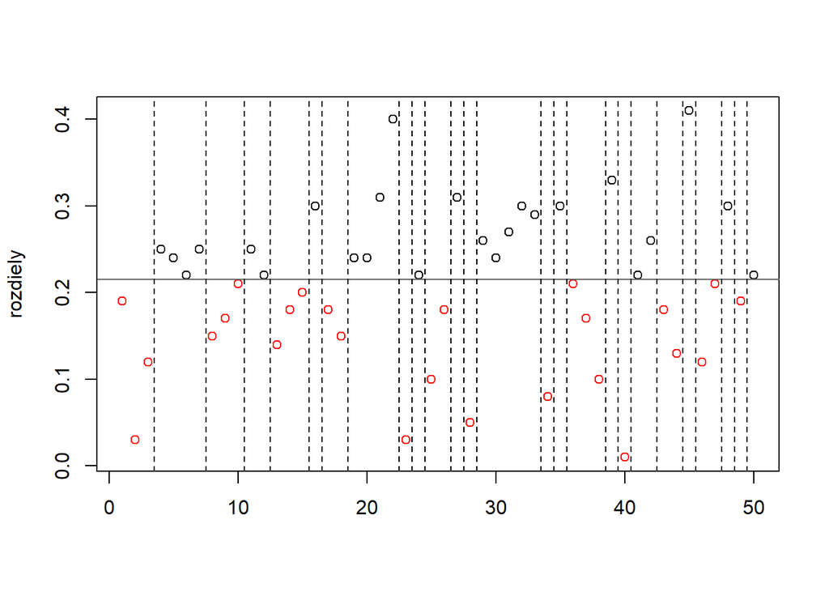

```
##
##  Runs Test
##
## data:  rozdiely
## statistic = 0, runs = 26, n1 = 25, n2 = 25, n = 50, p-value = 1
## alternative hypothesis: nonrandomness
```

```r
runs.test(rozdiely, plot = T)
```

```r
runs.test(rozdiely)$p.value
```

```
## [1] 1
```

```r
turning.point.test(rozdiely)$p.value
```

```
## [1] 0.4204681
```

Keďze pre oba testy platí, že $p.value > \alpha = 0.05$, nezamietame $H_0$, že dáta sú náhodné. Vďaka obom testom vieme povedať, že v nich nie je trend ani perióda.

### Vhodný neparametrický test

Tvrdenie o maximálnej zmene ideme testovať aj neparametricky. Keďže sú dáta symetrické (dokazovala som v príklade 1) môžme použiť Jednovýberový Wilcoxonov text, ktorý vyžaduje symetriu dát.

$$H_0 : \mu = 0.15(\leq0.15)\qquad H_1: \mu > 0.15$$

```r
wilcox.test(rozdiely, mu = 0.15, alternative = "greater")$p.value
```

```
## [1] 3.889501e-05
```

Keďže $p.value = 3.889501e-05 < \alpha = 0.05$ zamietame $H_0$ o mediáne.

## Príklad 5

Najprv musím overiť podmienky aby som mohla robiť ANOVA.

1. Dáta v skupinách musia byť normálne rozdelené.

```r
tapply(data$rozdiel, data$znacka, shapiro.test)
```

```
## $`1`
##
##  Shapiro-Wilk normality test
##
## data:  X[[i]]
## W = 0.97883, p-value = 0.9457
##
##
## $`2`
##
##  Shapiro-Wilk normality test
##
## data:  X[[i]]
## W = 0.95032, p-value = 0.6032
##
##
## $`3`
##
##  Shapiro-Wilk normality test
##
## data:  X[[i]]
## W = 0.98049, p-value = 0.9402
```

Keďže pre všetky značky vyšla $p.value > \alpha = 0.05$ nezamietame $H_0$ o tom, že všetky skupiny sú normálne rozdelené.

2. Potrebujem otestovať rovnosť disperzii v triedach

```r
bartlett.test(data$rozdiel, data$znacka)$p.value
```

```
## [1] 0.6457926
```

Keďže $p.value = 0.6457926 > \alpha = 0.05$ nezamietam $H_0$, disperzie v triedach sú rovnaké.

3. Faktorizujem dáta, kde značka bude faktor, ktorého nulovosť budem testovať.

```r
znacka <- factor(data$znacka)
```

Mám splnené všetky podmienky, môžem vykonať ANOVA.

```r
anova <- aov(data$rozdiel~znacka)
summary(anova)
```

```
##             Df Sum Sq  Mean Sq F value Pr(>F)
## znacka       2 0.0097 0.004851   0.616  0.545
## Residuals   47 0.3704 0.007881
```

Podľa posledného stĺpca viam, povedať, že rozdiely medzi strednými hodnotami sú štatisticky nevýznamné. Keďže nemám žiadnu triedu významne inú, nemusí robiť Post test. Ak by sme ich ale spravili, dostali by sme rovnaký výsledok, že triedy sú štatisticky rovnaké (ich stredné hodnoty).

```r
tpt <- TukeyHSD(anova)
tpt
```

```
##   Tukey multiple comparisons of means
##     95% family-wise confidence level
##
## Fit: aov(formula = data$rozdiel ~ znacka)
##
## $znacka
##       diff         lwr        upr     p adj
## 2-1  0.030 -0.04915894 0.10915894 0.6322554
## 3-1 -0.003 -0.07387562 0.06787562 0.9942321
## 3-2 -0.033 -0.10954305 0.04354305 0.5535952
```

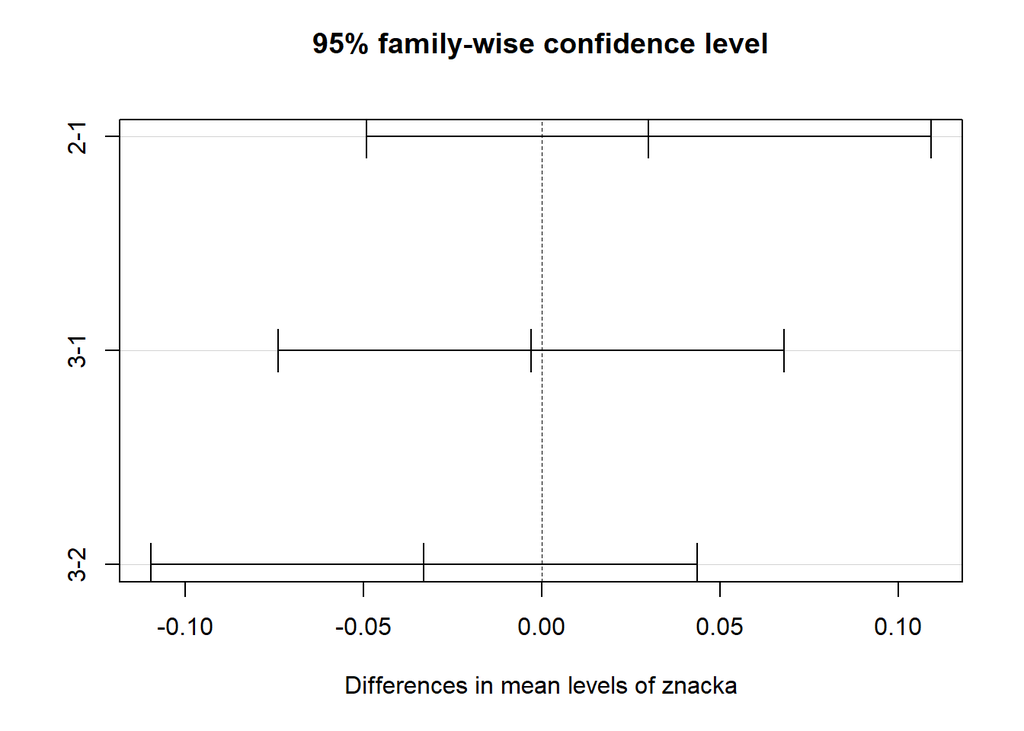

```r
plot(tpt)
```

Toto môžme vidieť aj na grafe.

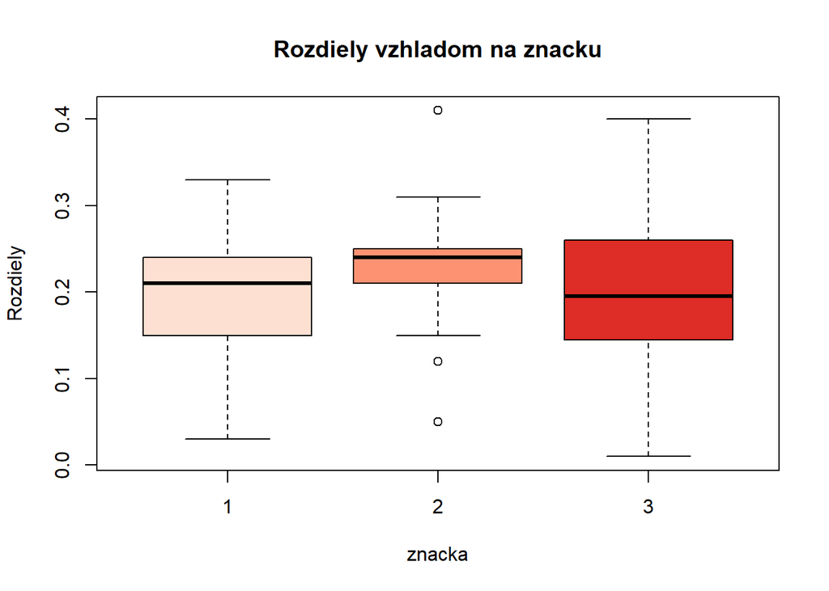

```r
boxplot(data$rozdiel~znacka, col = brewer.pal(3, "Reds"), ylab = "Rozdiely", main = "Rozdiely vzhladom na znacku")
```

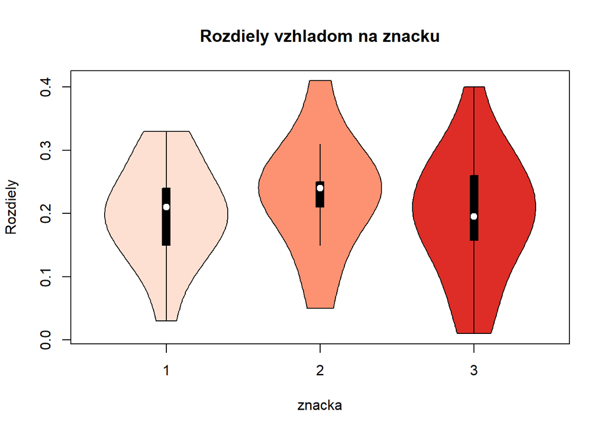

```r
vioplot(data$rozdiel~znacka, col = brewer.pal(3, "Reds"), ylab = "Rozdiely", main = "Rozdiely vzhladom na znacku")
```

Rozdiely medzi jednotlivými triedami nie sú viditeľné ani na boxplotoch ani na vioplotoch, čo dokazujú aj anova testy.